# Centrality in Social Networks

2022-03-25

# 1 Defining Centrality

What is centrality? In terms of graph theory, a **centrality metric** is a summary index of a node’s position in a graph, based on (sometimes weighted) *sums* or *averages* of one of three things (Borgatti and Everett 2006):

Borgatti, Stephen P, and Martin G Everett. 2006. “A Graph-Theoretic Perspective on Centrality.” *Social Networks* 28 (4): 466–84.

1. The *number* of **edges** that are directly **incident** upon that node.
2. The *length* of (usually **shortest**) **paths** that have that node as one of their **end nodes**.

   Or trails, or walks.
3. The *proportion* of (usually **shortest**) **paths** that have that node as one their **inner nodes**.

   Or trails, or walks.

   If you need a refresher on these graph theory concepts, see the lesson indirect connectivity in social networks.

Freeman, Linton C. 1979. “Centrality in Social Networks Conceptual Clarification.” *Social Networks* 1 (3): 215–39.

Sociologically, the notion of centrality is tied to such concepts as “status,” “prestige,” “importance,” “influence,” “popularity,” “reachability,” “brokerage,” and many more. So the more central nodes have higher status, are more popular, influential, broker more deals, and so forth.

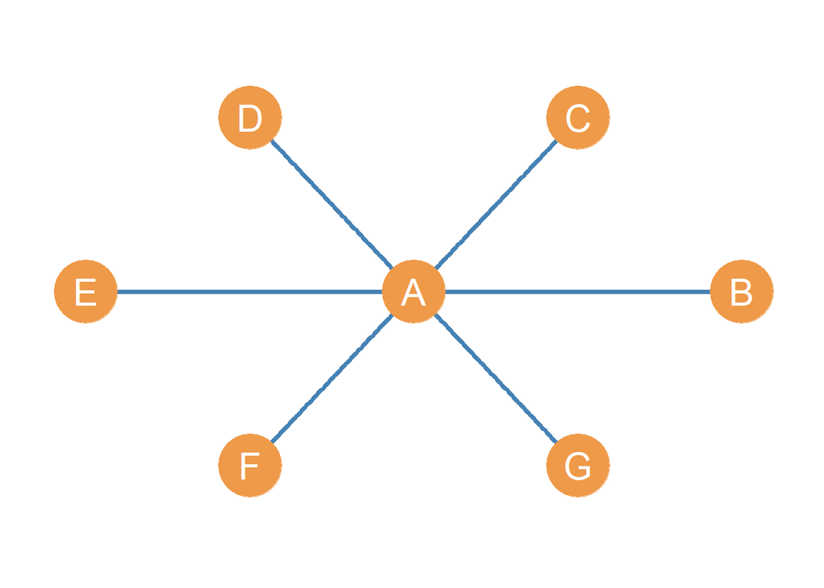

Figure 1.1: A star graph

These sociological concepts have to be kept distinct from any one centrality metric (remember the **three-step shuffle** in social network analysis discussed earlier), because the same concept can be measured by more than one centrality metric, and the same metric can point to many distinct sociological concepts, depending on the context, the type of social ties the network is constructed from, and the way either “goods” (e.g., information, advice, support, etc.) or “bads” (e.g., disease, gossip, violence etc.) “flow” through the network (Borgatti 2005).

Borgatti, Stephen P. 2005. “Centrality and Network Flow.” *Social Networks* 27 (1): 55–71.

# 2 The “big three” centrality metrics

Linton Freeman (1979), in the aforementioned paper, defined the three classic centrality metrics, roughly corresponding to the extent that a nodes accumulates one of the three network goods mentioned above. So the **degree centrality** metric deal with nodes that have more edges directly incident upon them (Nieminen 1974). The **closeness centrality** metric has to do with nodes that can reach more nodes via smallest **shortest paths** and thus accumulate as many of these paths in which they figure as the **origin node** as possible (Sabidussi 1966). Finally, the **betweenness centrality** metric has to do with a node’s accumulation of the largest share of shortest paths in which they intermediate between two other nodes, and thus featuring them as one of the **inner nodes** in the paths between others (Freeman 1977). Other centrality measures (like **eigenvector centrality** to be discussed later) can be seen as generalizations or special cases of any of these three basic notions.

Freeman, Linton C. 1979. “Centrality in Social Networks Conceptual Clarification.” *Social Networks* 1 (3): 215–39.

Nieminen, Juhani. 1974. “On the Centrality in a Graph.” *Scandinavian Journal of Psychology* 15 (1): 332–36.

Sabidussi, Gert. 1966. “The Centrality Index of a Graph.” *Psychometrika* 31 (4): 581–603.

Freeman, Linton C. 1977. “A Set of Measures of Centrality Based on Betweenness.” *Sociometry* 40 (1): 35–41.

The rest of the lesson goes over the basic interpretation and calculation (using the graph theory and matrix algebra tools discussed in previous lessons) of “big three” centrality metrics, as well as selected special cases and extensions to non-standard graphs.

Freeman showed that the three basic measures reach their theoretical *maximum* for the central node in a **star graph**, such as the one shown in Figure 1.1.

A star graph is a graph containing a **central** or **inner** node (in this case, node *A*), who is connected to all the other nodes in the graph, called the **satellite** or **outer** nodes. These nodes in contrast have only *one* connection and that is to the central node, none among themselves.

Because of these restrictions, it is easy to see that if $G = (V, E)$ is a star graph of order $n$, then we know that that graph size $m = |E|$ (the size of the edge set), has to be $n-1$.

# 3 Degree Centrality

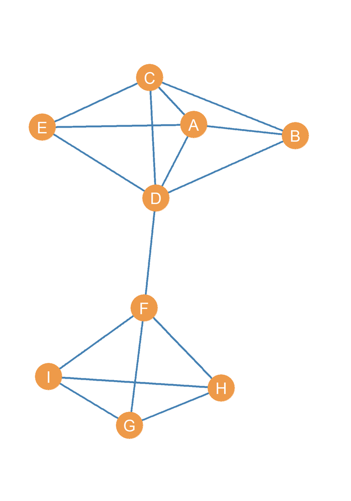

Figure 3.1: An undirected graph.

The first way of defining centrality is simply as a measure of how many alters an ego is connected to. This simply takes a node’s degree as introduced in the lesson on graph theory, and begins to consider this measure as a reflection of importance of the node in the network. The logic is that those with more direct connections to others, compared to those with fewer, hold a more prominent place in the network.

Once we have constructed the **adjancency matrix** for the network (**A**), then degree centrality is easy to calculate. As Equation (3.1) for a given node *i* the degree centrality is given by summing the entries of its corresponding row.

$$\begin{equation}
C_i^{DEG} = \sum_{j= 1}^{n}a_{ij}
\tag{3.1}
\end{equation}$$

Although it might seem a simple task to just add up the number of connections of each node, that is essentially what the below mathematical equation is doing! Mathematical notation plays an important role in expressing network measures in succinct formats.

Table 3.1: Degree centralities of nodes in an undirected graph.

| A | B | C | D | E | F | G | H | I |
| --- | --- | --- | --- | --- | --- | --- | --- | --- |
| 4 | 3 | 4 | 5 | 3 | 4 | 3 | 3 | 3 |

## 3.1 How to Read Equations for Matrix Operations

|  | a | b | c |
| --- | --- | --- | --- |
| **a** | - | 1 | 0 |
| **b** | 1 | - | 1 |
| **c** | 0 | 1 | - |

$C_D(a)=aa+ab+ac=1$  
$C_D(b)=ba+bb+bc=2$  
$C_D(c)=ca+cb+cb=1$

In the same way if we had the formula:

$$\begin{align*}
C_D(j) = \sum_{i = 1}^{n}a_{ij}
\end{align*}$$

Then it would be telling us to sum values of each column $j$ **down** each row $i$:

$C_D(a)=aa+ba+ca=1$  
$C_D(b)=ab+bb+cb=2$  
$C_D(c)=ac+bc+cc=1$

The sigma notation is useful for summarizing this repetitive process in a simple, condensed form.

## 3.2 Indegree and Outdegree Centrality

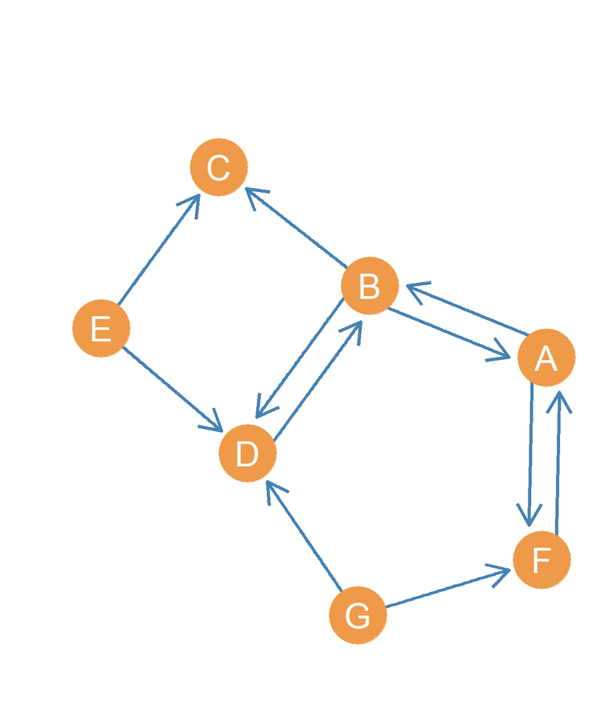

Figure 3.2: A directed graph.

If we are talking about a directed graph, then there are two types of centralities that can be calculated. On the one hand, we may be interested in how central a node is in terms of *sociability* or *expansiveness* that is how many other nodes in the graph a given node **sends** links to. This is called the **outdegree centrality** of that node, written as $C_i^{OUT}$. As with the undirected case, this is computed by summing across the rows of the **asymmetric adjacency matrix** corresponding to the directed graph in question, using the same equation (3.1) above:

$$\begin{equation}
C_j^{OUT} = \sum_{i = 1}^{n}a_{ij}
\tag{3.2}
\end{equation}$$

However, in a directed graph, we may also be interested in how *popular* or *sought after* by others a given node is. That is, how many other actors send ties *to* that node. In which case we need to sum across the **columns** of the asymmetric adjacency matrix, and modify the formula as follows:

$$\begin{equation}
C_j^{IN} = \sum_{j = 1}^{n}a_{ij}
\tag{3.3}
\end{equation}$$

Note that in this version of the equation, we are summing over *j* (the columns) not over *i* (the rows) as given by subscript under the $\sum$ symbol.

For instance, if we were to use equations (3.2) and (3.2) to calculate the outdegree and indegree centrality of each node from the asymmetric adjacency matrix corresponding to the graph shown in Figure 3.2, then we would up with the following centralities for each node:

Table 3.2: Out and Indegree centralities of nodes in a directed graph.

[output not shown]

# 4 Closeness Centrality

Sometimes it not important how many people you *directly* connected to. Instead, what is important is that you are **indirectly connected** to a lot of others. As we saw in the lesson on indirect connectivity, the best way to conceptualize indirect connectivity in social networks is via the idea of **shortest paths**. So if you can reach the most other people in the network via shortest paths with only a few hops, then you are better connected that someone who has to use longer paths to reach the same other people.

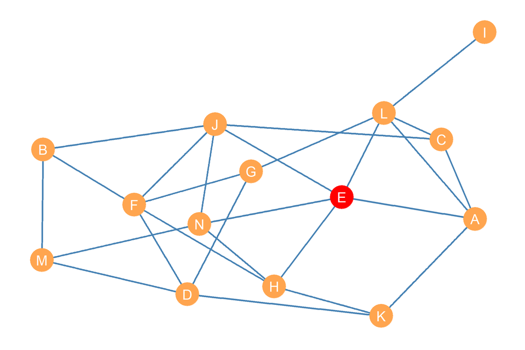

Figure 4.1: An undirected graph showing the node with the maximum closeness centrality (in red).

This insight serves as an inspiration for a measure of centrality based on **closeness**. The closeness between two nodes is the *inverse* of the **geodesic distance** them. Recall that the geodesic distance is given by the *length* of the shortest path linking two nodes in the graph. So the smallest the length of the shortest path separating two nodes in the graph, the closer the two nodes and vice versa.

This information is captured in a network’s geodesic **distance matrix**, as discussed in the lesson on matrices. For instance, take the graph shown in Figure 4.1. The distance matrix for which is shown in Table 4.1.

Table 4.1: Geodesic distance matrix for an undirected graph.

|  | A | B | C | D | E | F | G | H | J | K | L | M | N | I |
| --- | --- | --- | --- | --- | --- | --- | --- | --- | --- | --- | --- | --- | --- | --- |
| A | 0 | 3 | 1 | 2 | 1 | 3 | 2 | 2 | 2 | 1 | 1 | 3 | 2 | 2 |
| B | 3 | 0 | 2 | 2 | 2 | 1 | 2 | 2 | 1 | 3 | 3 | 1 | 2 | 4 |
| C | 1 | 2 | 0 | 3 | 2 | 2 | 2 | 3 | 1 | 2 | 1 | 3 | 2 | 2 |
| D | 2 | 2 | 3 | 0 | 3 | 1 | 1 | 2 | 2 | 1 | 2 | 1 | 2 | 3 |
| E | 1 | 2 | 2 | 3 | 0 | 2 | 2 | 1 | 1 | 2 | 1 | 2 | 1 | 2 |
| F | 3 | 1 | 2 | 1 | 2 | 0 | 1 | 1 | 1 | 2 | 2 | 2 | 2 | 3 |
| G | 2 | 2 | 2 | 1 | 2 | 1 | 0 | 2 | 2 | 2 | 1 | 2 | 3 | 2 |
| H | 2 | 2 | 3 | 2 | 1 | 1 | 2 | 0 | 2 | 1 | 2 | 2 | 1 | 3 |
| J | 2 | 1 | 1 | 2 | 1 | 1 | 2 | 2 | 0 | 3 | 2 | 2 | 1 | 3 |
| K | 1 | 3 | 2 | 1 | 2 | 2 | 2 | 1 | 3 | 0 | 2 | 2 | 2 | 3 |
| L | 1 | 3 | 1 | 2 | 1 | 2 | 1 | 2 | 2 | 2 | 0 | 3 | 2 | 1 |
| M | 3 | 1 | 3 | 1 | 2 | 2 | 2 | 2 | 2 | 2 | 3 | 0 | 1 | 4 |
| N | 2 | 2 | 2 | 2 | 1 | 2 | 3 | 1 | 1 | 2 | 2 | 1 | 0 | 3 |
| I | 2 | 4 | 2 | 3 | 2 | 3 | 2 | 3 | 3 | 3 | 1 | 4 | 3 | 0 |

As shown in the table, a node like *I*, who seems to be at the outskirts of the network, also shows up as having the largest geodesic distances from other nodes in the graph. Other nodes, like *E*, *G*, and *L* seem to be “closer” to others, in terms of having smaller geodesic distances.

That means that we can use the distance table to come up with a measure of centrality called **closeness centrality** for each node. We can do that by adding up the entries corresponding to each row in the distance matrix ($\sum_i d_{ij}$), to get a summary the total pairwise distances separating the node corresponding to row *i* in the matrix from the other nodes listed in each column.

Note that because closeness is better than “farness” we would want the node with *highest closeness centrality* to be the one with the *smallest* sum of pairwise distances. This can be calculated using the following equation:

$$\begin{equation}
C_i^{CLOS} = N\frac{1}{\sum_{i = j}^{n}d_{ij}}
\tag{4.1}
\end{equation}$$

In equation (4.1), the denominator is the sum of the sum (across columns) for each row in Table 4.1. We take the mathematical *inverse* (dividing one by the sum of distances) so that way, the smallest number comes out on top and the bigger number comes out of the bottom. We multiply the inverse sum of distances for each node by the constant *N* (the graph order) because dividing one by a big number results in very small numbers, which could be hard to interpret.

Applying equation (4.1) to the distance matrix shown in Table 4.1, results in the following closeness centrality scores for each node in Figure 4.1.

Table 4.2: Closeness centrality scores.

| A | B | C | D | E | F | G | H | J | K | L | M | N | I |
| --- | --- | --- | --- | --- | --- | --- | --- | --- | --- | --- | --- | --- | --- |
| 7.8 | 7 | 7.5 | 7.8 | 8.9 | 8.5 | 8.2 | 8.2 | 8.5 | 7.5 | 8.5 | 7 | 8.2 | 5.6 |

The closeness centrality scores listed in Table 4.2 agree with our informal impressions. Node *I* comes out at the bottom ($CC_I^{CLOS} = 5.6$), showing it to be the one with the least closenes centrality, given the relatively large geodesic distances separating it from the other nodes in the graph. Node *E* (marked red in Figure 4.1) comes out on top ($CC_E^{CLOS} = 8.9$), given its relative geodesic proximity to other nodes in the graph.

As we will see later, having closeness centrality information for nodes in a graph can be useful. For instance, if Figure 4.1) was a social network, and we wanted to spread an innovation or a new product among the actors in the fastest amount of time, we would want to give it to node *E* first. Note however that if something **bad** (like a disease) was spreading across the network, then it would also be very bad if actor *E* got it first!

See the discussion [here](http://www.analytictech.com/networks/centaids.htm).

# 5 Betweenness Centrality

Recall that in our discussion of shortest paths between pair of nodes in the lesson on indirect connections, we noted the importance of the inner nodes that *intervene* or *mediate* between a node that wants to reach another one. Nodes that stand in these **brokerage** or **gatekeeper** slots in the network, occupy an important position (Marsden 1983), and this is different from having a lot of contacts (like degree centrality), or being able to reach lots of other nodes by traversing relatively small distances (like closeness centrality). Instead, this is about being *in-between* the indirect communications of other nodes in graph. We can compute a centrality metric for each node called **betweenness centrality** that captures this idea Freeman (1980).

Marsden, Peter V. 1983. “Restricted Access in Networks and Models of Power.” *American Journal of Sociology* 88 (4): 686–717.

Freeman, Linton C. 1980. “The Gatekeeper, Pair-Dependency and Structural Centrality.” *Quality and Quantity* 14 (4): 585–92.

Figure 5.1: An undirected graph showing the node with the maximum betweenness centrality (in red)

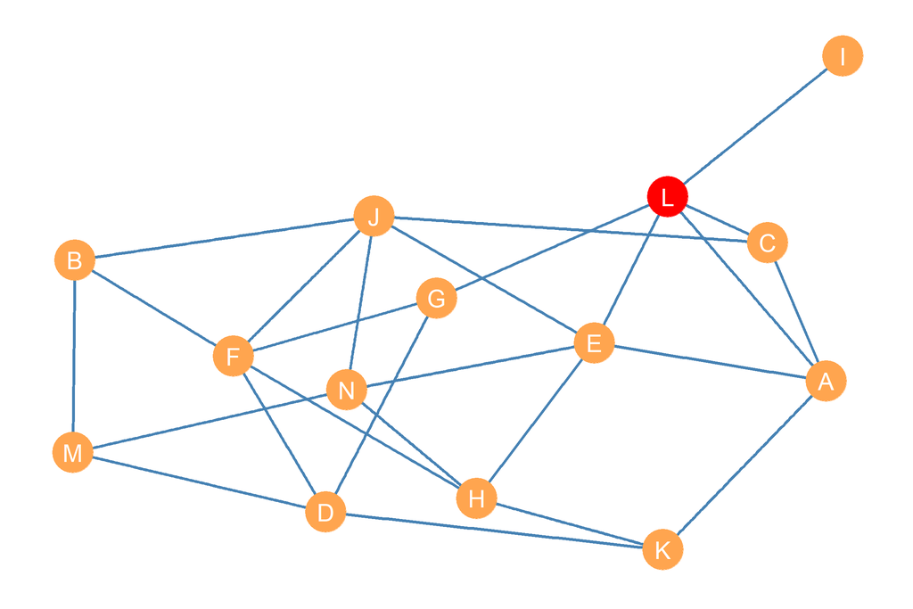

This shortest path list would look like this:

1. $\{KH, HF, FJ\}$
2. $\{KD, DF, FJ\}$
3. $\{KH, HN, NJ\}$
4. $\{KA, AC, CJ\}$
5. $\{KA, AE, EJ\}$
6. $\{KH, HE, EJ\}$

There are six shortest paths of length three indirectly connecting actors *K* and *J* in Figure 4.1, with nodes $\{A, C, D, E, F, H, N\}$ showing up as an inner node in at least one of those paths. To see which other actor in the network is the most frequent intermediary between *J* and *K*, we can create a list with the number of times each of these nodes shows up as an intermediary in this shortest path list. This would look like this:

| Node | Freq. | Prop. |
| --- | --- | --- |
| A | 2 | 0.33 |
| C | 1 | 0.17 |
| D | 1 | 0.17 |
| E | 2 | 0.33 |
| F | 2 | 0.33 |
| H | 3 | 0.50 |
| N | 1 | 0.17 |

$$\begin{equation}
p_{KJ}(H) = \frac{g_{KJ}(H)}{G_KJ} = \frac{3}{6} = 0.5
\tag{5.1}
\end{equation}$$

In equation (5.1), $g_{KJ}(H)$ is the number of shortest paths linking *K* and *J* featuring *H* as an inner node, and $g_{KJ}$ is the total number of paths linking *K* and *J*. Freeman (1980) calls this measure the **pair-dependency** of actor *K* on actor *H* to reach a given node *J*. In this case, $g_{KJ}(H) = 3$ and $g_{KJ} = 6$, which means that actor *K* depends on actor *H* for fifty percent of their shortest path access to *J*. Making *H* the actor in the network *J* depends on the most to be able to reach *J*.

Freeman, Linton C. 1980. “The Gatekeeper, Pair-Dependency and Structural Centrality.” *Quality and Quantity* 14 (4): 585–92.

Generalizing this approach, we can do the same for each triplet of actors *i*, *j*, and *k* in the network. This is the basis for calculating betweenness centrality. That is, we can count the number of times *k* stands on the shortest path between two other actors *i* and *j*. We can all this number $g_{ikj}$. We can then divide it by the total number of shortest paths linking actors *i* and *j* in the network, which we refer by $g_{ij}$. Remember that two actors can be indirectly linked by *multiple shortest paths of the same length*, and that we can figure out how many short paths links pairs of actors in the network using the **shortest paths matrix**.

This ratio, written $\frac{g_{ikj}}{g_{ij}}$ then gives us the *proportion* of shortest paths in the network that have *i* and *j* as the end nodes and that feature *k* as an intermediary inner node. This can range from zero (no shortest paths between *i* and *j* feature node *k* as an intermediary) to one (all the shortest paths between *i* and *j* feature node *k* as an intermediary).

We can then use the following equation to compute the average of this proportion for each node *k* across each pair of actors in the network *i* and *j*:

$$\begin{equation}
C_k^{BET} = \sum_i \sum_j \frac{g_{ikj}}{g_{ij}}
\tag{5.2}
\end{equation}$$

Computing this quantity for the graph shown in Figure 4.1, yields the betweenness centrality scores shown in Table 5.1.

Table 5.1: Betweenness centrality scores.

| A | B | C | D | E | F | G | H | J | K | L | M | N | I |
| --- | --- | --- | --- | --- | --- | --- | --- | --- | --- | --- | --- | --- | --- |
| 5 | 1.5 | 3 | 6.8 | 11.4 | 9.3 | 6.3 | 4.8 | 10.8 | 3.7 | 16.4 | 2.8 | 5.3 | 0 |

The numbers in the Table can be readily interpreted as percentages. Thus, the fact that node *J* has a a betweenness centrality score of 10.8 tells us that they stand in about 11% of the shortest paths between pairs of nodes in the graph. Interestingly, as shown in Figure 5.1, the node that ends up with the highest betweenness score is *L* ($C_L^{BET} = 16.4$), mostly due to the fact that node *I*, who has the lowest possible betweenness score of zero, depends on this node for access to every other actor in the network.

Note also that the fact two different nodes end up being ranked first in terms of closeness and betweenness centrality in the same network (compare Figure 4.1 and Figure 5.1), tells us that these are analytically distinct measures of node position.

# 6 Centralities in the Star Graph

Degree, Closeness, and Betweenness centralities have an interesting property that provides a conceptual connection between them. Consider the star graph of order nine shown in Figure 6.1 with central node *A*. The degree, closeness, and betweenness centralities of the different nodes are shown in Table 6.1.

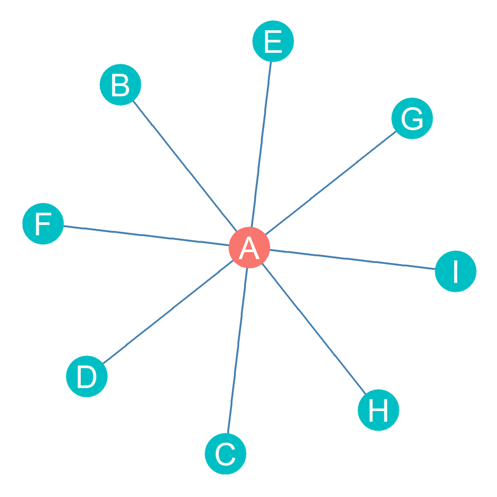

Figure 6.1: A star graph of order nine.

Of course, by definition, we know beforehand that the central node in a star graph has to have the highest degree, since the degree of peripheral nodes is fixed to one and the degree of the central node is always $n-1$, where $n$ is the graph order.

However, note also that the central node has to have the highest closeness, since it is directed by a path of length one (and edge) to every peripheral node, but each peripheral node can only reach other peripheral nodes in the graph by a path of length two. They are farther away from other nodes than the central node.

Finally, note that the central node in the star will also always have the highest betweenness because each of the paths of length two connecting every pair of peripheral nodes to one another *has* to include the central node. So it serves as the intermediary between any communication between peripheral nodes.

Table 6.1: Centralities in a star graph.

|  | A | B | C | D | E | F | G | H | I |
| --- | --- | --- | --- | --- | --- | --- | --- | --- | --- |
| Degree | 8.0 | 1.0 | 1.0 | 1.0 | 1.0 | 1.0 | 1.0 | 1.0 | 1.0 |
| Closeness | 10.1 | 5.4 | 5.4 | 5.4 | 5.4 | 5.4 | 5.4 | 5.4 | 5.4 |
| Betwenness | 28.0 | 0.0 | 0.0 | 0.0 | 0.0 | 0.0 | 0.0 | 0.0 | 0.0 |

The mathematical sociologist **Linton Freeman (1979)** thus thinks that the “big three” centrality measures are the big three precisely because they are maximized for the central node in a star graph.

Freeman, Linton C. 1979. “Centrality in Social Networks Conceptual Clarification.” *Social Networks* 1 (3): 215–39.

# 7 Eigenvector Centrality

Sometimes, when it comes to being connected, what matter is not *how many* other people you know. Instead, what is important is being connected to well connected others. Degree-based measures don’t capture this intuition, because every connection counts the same, regardless of whether that connection goes to a well-connected other or to a poorly connected other.

Table 7.1: Degree centralities of nodes in the graph below.

| Mag | Mag | Mag | Red | Blue | Gray | Tan | Tan | Tan | Tan | Tan | Tan | Tan | Tan | Tan | Tan | Tan | Tan | Tan | Tan | Tan | Tan |
| --- | --- | --- | --- | --- | --- | --- | --- | --- | --- | --- | --- | --- | --- | --- | --- | --- | --- | --- | --- | --- | --- |
| 6 | 6 | 6 | 3 | 3 | 2 | 1 | 1 | 1 | 1 | 1 | 1 | 1 | 1 | 1 | 1 | 1 | 1 | 1 | 1 | 1 | 1 |

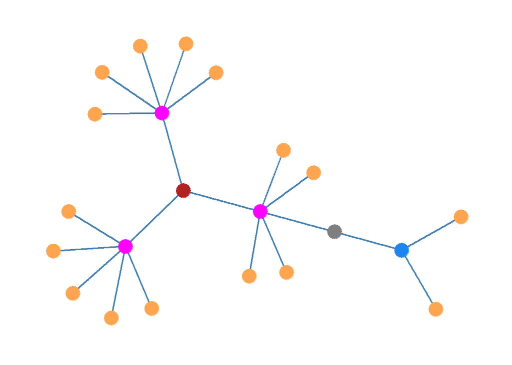

Figure 7.1: An undireced graph with degree centrality indicated by node color.

Consider, for instance, the graph shown in Figure 7.1. The corresponding **degree set** of the graph (by node color) is shown as Table 7.1. In that figure, if we go by the simple degree centrality measure, the nodes shown in magenta, are the best connected ones. Each of these nodes connects to six others. The nodes shown in tan are the least well connected; each of those connect to only one neighbor The node shown in gray is marginally better connected than the tan nodes, featuring two connections. Finally, the nodes in red and blue are tied for “in between” in terms of degree centrality; each connects to three others.

Yet, given the previous reflections, there’s a lingering suspicion that the best connected node in the graph is actually the red node, because even though that node only has three connections, all three go to well connected people. Thus, the centrality “tie” with the blue node (based on degree) is misleading, if we weighed the ties of the red based on the degree of the nodes they connect to, they should count for more than the three ties the blue node has, which go to less well-connected people.

Table 7.2: Eigenvector centralities of nodes in the graph above

| Mag | Mag | Mag | Red | Blue | Gray | Tan | Tan | Tan | Tan | Tan | Tan | Tan | Tan | Tan | Tan | Tan | Tan | Tan | Tan | Tan | Tan |
| --- | --- | --- | --- | --- | --- | --- | --- | --- | --- | --- | --- | --- | --- | --- | --- | --- | --- | --- | --- | --- | --- |
| 0.99 | 0.93 | 0.93 | 1 | 0.2 | 0.42 | 0.35 | 0.35 | 0.35 | 0.35 | 0.33 | 0.33 | 0.33 | 0.33 | 0.33 | 0.33 | 0.33 | 0.33 | 0.33 | 0.33 | 0.07 | 0.07 |

In the same way, the magenta degree centrality advantage is also misleading, because even though the magenta nodes have a larger number of connections than the red node, these go to less well-connected others. The red node knows three popular people, but the popular people only know other less popular people.

The same reasoning applies to our questioning the presumed advantage that the blue node has over the gray node. Based on degree the blue node is better connected ($C_{Blue}^{DEG} = 3$) than the gray node ($C_{Blk}^{DEG} = 2$), but one of the gray node’s connections goes to a well-connected magenta node (who has a connection to the even better-connected red node), so we would like to say that the gray node is actually better-positioned in the network, in the sense of having connections to well-connected others.

All of these reflections lead us to the conclusion that degree centrality may be an incomplete measure of node position, because it only takes into account the number of connection a node has, not who those connections are to. A more general version of centrality would capture that.

If we had to express it as an equation using the terms of the network’s **adjacency matrix**, then the measure of centrality we are looking for, where the centrality of a node *i* is proportional to the centrality of their neighbors *j* would be:

$$\begin{equation}
x_i = \sum_j A_{ij}x_j
\tag{7.1}
\end{equation}$$

So what equation (7.1) says is that the centrality of node *i* ($x_i$) is just the sum of the centralities ($x_j$) of the nodes they are connected to, as the right-hand side of the sum is only going to be non-zero when $A_{ij} = 1$. But how are we going to figure out the centralities of the other nodes if we don’t even node the centrality of the node that we are trying to compute the centrality for? It seems like we are stuck in a circle. To figure out the centrality of node *i* we need to already know the centrality of the other nodes *j*, but we don’t know those to begin with!

Phillip Bonacich, a Professor Emeritus in the Sociology Department at UCLA, developed a measure of centrality that solves this conundum and does what we are looking for (Bonacich 1972). The measure is based on a **matrix factorization** technique called the **eigenvector decomposition**, where the matrix in question is the network’s **adjacency matrix**. Because of this, this centrality measure carries the (unwieldy) name of **eigenvector centrality**. But don’t be scared by the “mathy” name. The concept behind the measure is relatively simple, and it is precisely what we are looking for.

Bonacich, Phillip. 1972. “Factoring and Weighting Approaches to Status Scores and Clique Identification.” *Journal of Mathematical Sociology* 2 (1): 113–20.

Also generally known as the [**eigendecomposition**](https://en.wikipedia.org/wiki/Eigendecomposition_of_a_matrix) of the matrix.

How does it work? Imagine that we start with regular old degree. This gives us the degree distribution and node ranking shown in Table 7.1; for each neighbor they have, each node gets one degree “point.” Now in the second step, we can give each node extra points for each of the *friends their first step friends have*. In the third step, we can give node even more extra points for each *friend that their first step friends’ friends have*, but discount these points a bit, because friends of friends are less important than friends. Then we keep going and give each node points for each *friend that their second step friends of friends’ friends have* but discount these even more because friends of friends of friends are obviously less important than friends of friends. We can continue doing this until we can’t go anymore (we reach the mathematical limit of the network in terms of how many friends, of friends, of friends, etc. people can have given the graph order and size). In his classic paper, Bonacich showed that the eigendecomposition of the network’s adjacency matrix (technically the **eigenvector** corresponding to the largest **eigenvalue** of the adjacency matrix with all positive numbers) give us these scores, without having to go through the whole friends, of friends, of friends, of friends, etc. thing. Matrix Algebra magic!

Table 7.2 shows the eigenvector centrality scores for the network shown in Figure 7.1. To aid interpretation, eigenvector centrality scores are *normalized* so that the top node receives an eigenvector centrality of 1.0 and then other nodes receive smaller scores proportional to how close their eigenvector centrality score is to the top node. Nodes with the lowest eigenvector centralities in the graph receive scores closer to zero.

In the same way, note that the four tan nodes connected to the magenta node who’s connected to the gray node get a slightly larger eigenvector centrality score than the other tan nodes ($C_{Tan}^{EIG} = 0.35$). The reason is that these tan nodes get a few extra centrality points from the their indirect (two-step) connection to the gray node and their three-step connection to the gray node’s contacts. Note also that the blue node, presumably “tied” with the red node in terms of degree, ends up in the diametrically opposite place from this node in terms of eigenvector centrality: in the bottom three ($C_{Blue}^{EIG} = 0.20$). The reason is that while the blue node, like the red node, has three connections two of those go to nodes with no other friends (so no extra friends of friends points), and the other one goes to a node that only has degree centrality equal to 2. So the blue node is the less well-connected if by that we mean being connected to connected others.

Finally note that two tan nodes receive the lowest eigenvector centrality scores ($C_{Tan}^{EIG} = 0.07$). As you may have guessed, those are the two tan nodes shown in the rightmost area of the network diagram. The reason for this is that in contrast to the other tan nodes, who are connected to more central magenta nodes, those are connected to the not not-very well-connected blue node (who’s connected to the not very well-connected gray node), so they derive very little extra points from those connections.